# Quick start guide of single-cell TI with Totem

Elo lab - https://elolab.utu.fi

20/04/2023

## QuickStart

This tutorial is a quick start guide with `Totem`, a user-friendly tree-shaped single-cell trajectory inference (TI) method (Smolander, Junttila, and Elo 2022). The minimum requirement to run `Totem` is a low-dimensional result, such as tSNE or UMAP, as far as this low-dimensional representation represents fairly the cell dynamic process in study, e.g., cell cycle, activation or differentiation.

Commonly one is interested in inferring cell trajectory after running an integration and/or clustering analysis. In either case the scRNA-seq data was most likely projected onto the low-dimensional space, such as PCA and UMAP, along the analysis. Under this scenario, the user might be interested in preserving these low-dimensional reductions during the cell TI analysis.

With this in mind, this quick start guide applies `Totem`’s TI to a scRNA-seq data set of **CD34+ bone marrow cells** (replicate 1) used as an example in the `Palantir`’s TI publication (Setty et al. 2019) and publicly available at Human Cell Atlas Portal (link: https://data.humancellatlas.org/explore/projects/091cf39b-01bc-42e5-9437-f419a66c8a45). The processed data set with tSNE projection, cluster identities,`palantir` pseudotime, transformed log-normalized and raw data provided at [human_cd34_bm_rep1.h5ad](https://data.humancellatlas.org/explore/projects/091cf39b-01bc-42e5-9437-f419a66c8a45/project-matrices) will be used for demonstration of the user-friendliness and experience of `Totem`’s TI analysis. The `human_cd34_bm_rep1.h5ad` `anndata` `h5ad` object was downloaded, parsed and distributed as a RDS `SingleCellExperiment` class object at `data/human_cd34_bm_rep1.rds`. The R script used for this object is provided at `scripts/download_h5ad_to_SCE_rds_script.R`.

The content of this tutorial is enumerated and described below.

1. Preprocessing: importing data to R and preparing it to `Totem`
2. `Totem`’s TI: two-step `Totem`’s TI workflow:

   2.1. clustering & multiple spanning trees (MSTs)

   2.2. smoothing selected clustering/MSTs
3. Visualization: visualizing `Totem`’s cell connectivity, clustering, and trajectory’s topology
4. Pseudotime: re-rooting and comparison of `Totem`’s pseudotime estimates to those of `Palantir`

## (1) Preprocessing

Load the following `R` packages.

```r
# Load packages
library("dplyr")
library("Totem")
library("scater")
library("ggplot2")
library("SingleCellExperiment")
```

**What does every package?**

- `dplyr` v.1.1.0 (Wickham et al. 2022): data wrangling, e.g., *piping* data with `%>%`
- `ggplot2` v.3.4.1 (Wickham 2016): data visualization
- `Totem` v.0.99.2 (Smolander, Junttila, and Elo 2022): trajectory inference
- `scater` v.1.26.1 (McCarthy et al. 2017): `Bioconductor` scRNA toolkit - used for low-dimensional visualization
- `SingleCellExperiment` v.1.20.0 (Amezquita et al. 2020): `Bioconductor` single-cell data object - `R` class object used to interact with `Totem`

Set seed to keep the reproducibility of the analyses generated.

```r
# Set seed
set.seed(1204)
```

Import the `RDS` `SingleCellExperiment` class object storing the scRNA-seq data set with the function `readRDS` (file available at: `data/human_cd34_bm_rep1.rds`).

```r
## Import the scRNA-seq SCE object
sce <- readRDS(file = "../data/human_cd34_bm_rep1.rds")
```

**What is a `SingleCellExperiment` class object?**

`Totem` conveniently uses the `SingleCellExperiment` (`SCE` for short) `R` package and class to store all the information that generates in its workflow. This can be accessed through: `metadata(sce)$totem` (which returns a list of objects generated in the `Totem` workflow).

A `SCE` object can store several gene expression assays (raw, log counts, etc), metadata (cell/gene) and dimensional reduction data. Please have a look into the [Chapter 4 The SingleCellExperiment class](https://bioconductor.org/books/3.17/OSCA.intro/the-singlecellexperiment-class.html) of the [OSCA](https://bioconductor.org/books/3.17/OSCA.intro/) book to learn more about the `SingleCellExperiment` class and functionality.

Before starting the workflow, we exclude any potential non expressed gene from our SCE object.

```r
## Prepare data for Totem: remove non-expressed genes
sce <- PrepareTotem(object = sce)
```

```
## The data matrix has 14651 features.
```

```
## The data matrix has 5780 cells.
```

```
## Please note that the filtering of poor-quality cells needs to be
##           done before Totem analysis. In addition, the cells need to be part of
##           a single, connected, tree-shaped trajectory
##           (not multiple disconnected trajectories.
```

```
## 14624/14651 features remain after filtering genes with only zero values.
```

The `sce` object contains the assays counts, logcounts, scaled, the cell metadata clusters, palantir_pseudotime, palantir_diff_potential, cell_types_long, cell_types_short with 14624 genes and 5780 cells.

## (2) `Totem`’s TI

The two-step `Totem`’s TI workflow consists:

1. clustering & multiple spanning trees (MSTs): `RunClustering(...)`
2. smoothing selected clustering/MSTs: `SelectClusterings(...)` followed by `RunSmoothing(...)`

The only input required is the `SingleCellExperiment` object named `sce` with a low-dimensional reduction result in `reducedDim(sce)`, which in this case is a `tsne` with two dimensions (run the following to see the first tSNE 6 cell coordinates - `head(reducedDim(sce))`).

```r
## Totem's TI workflow:
# (1) clustering dimensional reduction w/ CLARA (k-medoids), MSTs
# (2) smoothing best clustering/MSTs w/ principal curves algorithm
set.seed(123) # keep reproducibility
sce <- RunClustering(object = sce) %>%
  SelectClusterings(object = .) %>%
  RunSmoothing(object = .)
```

```
## using tsne as the dim.reduced data
```

```
## number of clustering results: 10000
```

**What does `%>%` mean/do?**

The expression `%>%` is a pipe. Pipes are a convenient computational way of passing the output generated by the previous command to the input of the next command. If you’re not familiar with pipes (`%>%` coming from the package `dplyr`), you can run the equivalent to the previous code without using pipes.

```r
## Totem's TI workflow:
# (1) clustering dimensional reduction w/ CLARA (k-medoids), MSTs
# (2) smoothing best clustering/MSTs w/ principal curves algorithm
set.seed(123) # keep reproducibility
sce <- RunClustering(object = sce)
sce <- SelectClusterings(object = sce)
sce <- RunSmoothing(object = sce)
```

**What does every individual function above?**

## (3) Visualization

The `Totem`’s cell connectivities, clustering/MST and trajectory can be visual inspected after running `Totem`’s TI method.

### Cell connectivity

**Cell connectivity** is a novel concept introduced in `Totem`. For a given clustering result and the respective MST, the connectivity of a cell cluster consists in the ratio of its connections to other clusters by the number of clusters. Higher the value farther the distance for the leafs/ending points of the trajectory and, thus, more likely to represent, e.g., branching points (see Fig.4 (Smolander, Junttila, and Elo 2022)).

`Totem` relies on the `dynplot` (Cannoodt and Saelens 2021) package for visualization which requires to give the dimensional reduction result as a parameter (`viz.dim.red`). Thus the tSNE dimensional reduction is first retrieved from the `sce` object with `dim_red <- reducedDim(sce, "tsne")` and given as parameter (``viz.dim.red = dim_red`) to the function `VizCellConnectivity()` together with the `sce` object to plot cell connectivities.

```
## Coloring by milestone
```

```
## Using milestone_percentages from trajectory
```

```
## Coloring by expression
```

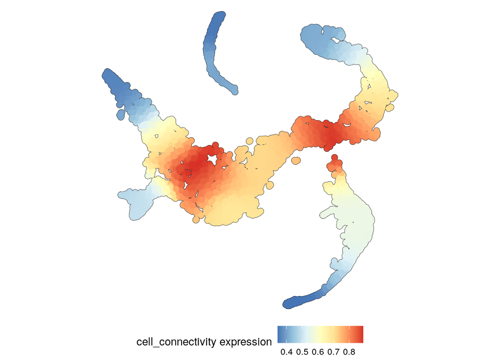

```r
## Visualization of cell connectivity
dim_red <- reducedDim(sce, "tsne") # retrieve tSNE
VizCellConnectivity(object = sce, viz.dim.red = dim_red) # plot
```

The cell connectivity plot suggests that HSC and MyP are branching points during hematopoiesis.

### Clustering/MST

Next the best clustering and MST can be inspected with the function `VizMST()`. The name of the best clustering and MST needs to be retrieved (`select.cluster <- names(metadata(sce)$totem$slingshot_trajectory)`) and given as parameter (`clustering.names = select.cluster`). In addition, the `sce` object and tSNE result (`viz.dim.red = dim_red)`) are also given.

In the code below it is also plotted the `Palantir`’s cluster and cell types abbreviated. For this end it is used the function `plotReducedDim()` from the `scater` package (read more about the function `?plotReducedDim`).

```
## Coloring by milestone
##
## Using milestone_percentages from trajectory
```

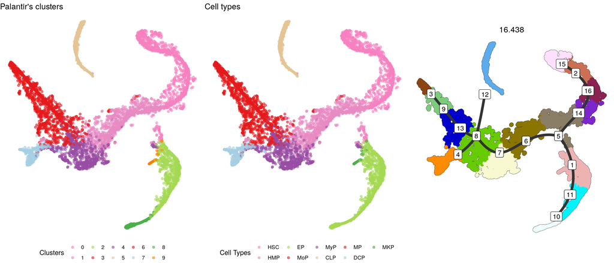

```r
## Visualization of clustering/MST
select.cluster <- names(metadata(sce)$totem$slingshot_trajectory) # retrieve the name of the best cluster
cowplot::plot_grid(
  plotReducedDim(sce, dimred = "tsne", color_by = "clusters") +
    scale_color_manual(name= "Clusters", values=unlist(metadata(sce)$cluster_colors)) +
    ggtitle("Palantir's clusters") +
    theme_void() +
    theme(legend.position = "bottom"),
  plotReducedDim(sce, dimred = "tsne", color_by = "cell_types_short") +
    scale_color_manual(name= "Cell Types",
                       values=as.character(unlist(metadata(sce)$cluster_colors)[!duplicated(levels(sce$cell_types_short))])) +
    ggtitle("Cell types") +
    theme_void() +
    theme(legend.position = "bottom"),
  VizMST(object = sce, clustering.names = select.cluster, viz.dim.red = dim_red),
  ncol=3, align = "v"
)
```

## (4) Pseudotime

### Rooting

At this stage the root can be defined by giving the cluster number. From the plots visualized above cluster 15 seems to be a good candidate for the root which corresponds to the more imature HSC cell type (hematopoietic stem cells).

The `ChangeTrajRoot()` allow us to change the root by providing the name of the clustering/MST result (`traj.name = select.cluster`) and the cluster number that should be root (`root.cluster = root.cluster`).

This step can be skipped, but, in that case, the root will be randomly assigned.

```r
## Define the root of the cell trajectory
root.cluster <- 15
sce <- ChangeTrajRoot(object = sce, traj.name = select.cluster, root.cluster = root.cluster)
```

### Pseudotime

The smoothed, rooted and directed trajectory for the best clustering/MST result with (`plot.pseudotime = TRUE`) or without (`plot.pseudotime = FALSE`) pseudotime can be highlighted below with the function `VizSmoothedTraj()`.

```
## Coloring by milestone
```

```
## Using milestone_percentages from trajectory
```

```
## Pseudotime not provided, will calculate pseudotime from root milestone
```

```
## root cell or milestone not provided, trying first outgoing milestone_id
```

```
## Using '15' as root
```

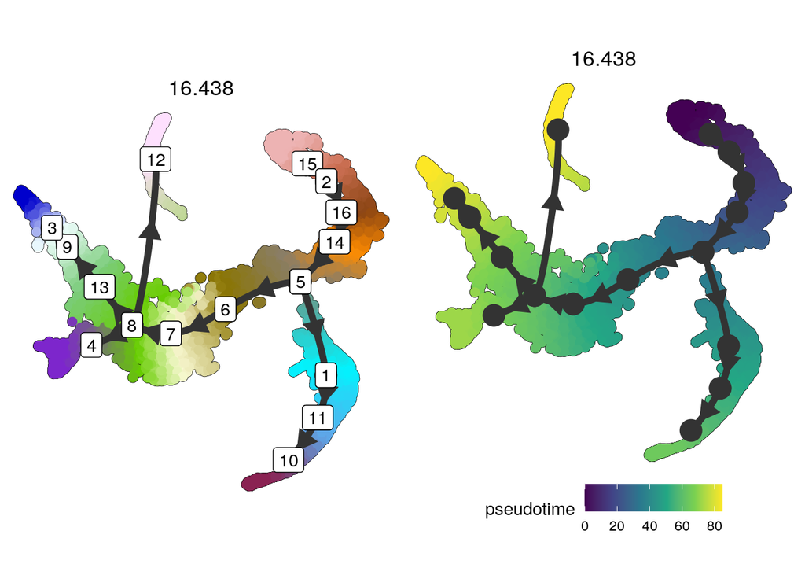

```r
cowplot::plot_grid(
  VizSmoothedTraj(object = sce,
                  traj.names = select.cluster,
                  viz.dim.red = dim_red, plot.pseudotime = FALSE),
  VizSmoothedTraj(object = sce,
                  traj.names = select.cluster,
                  viz.dim.red = dim_red, plot.pseudotime = TRUE),
  ncol=2
)
```

### Pseudotime comparison

`Totem`’s pseudotime (on the left side) can be compared with `Palantir`’s pseudotime (on the right side). The *Pearson*’s correlation between pseudotimes was 0.88.

```
## Pseudotime not provided, will calculate pseudotime from root milestone
```

```
## root cell or milestone not provided, trying first outgoing milestone_id
```

```
## Using '15' as root
```

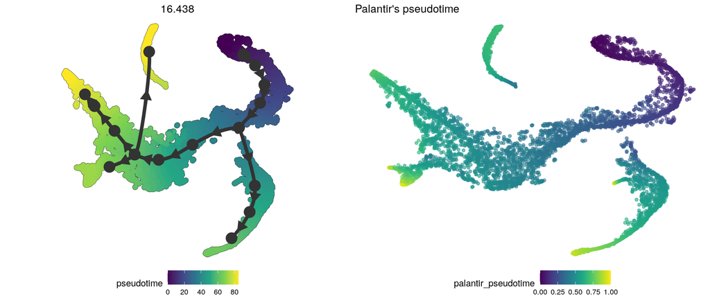

```r
## Compare Totem pseudotime against ground-truth
cowplot::plot_grid(
  (VizSmoothedTraj(object = sce,
                traj.names = select.cluster,
                viz.dim.red = dim_red, plot.pseudotime = TRUE) +
     ggtitle("Totem")),
  (plotReducedDim(sce, dimred = "tsne", colour_by = "palantir_pseudotime") +
      ggtitle("Palantir's pseudotime")) +
    theme_void() +
    theme(legend.position = "bottom"),
   ncol=2
   )
```

Despite the good correlation between pseudotime obtained between `Totem`’s and `Palantir`’s and the correct prediction of terminal states once the root was provided, the lymphoid lineage was wrongly predicted. CLP (common lymphoid progenitor) should had been diverging from HSC (hematopoietic stem cells).

One of the reasons that may explain this wrong prediction is how well the low-dimensional representation used for clustering fairly represents the relationship between cell types. The CLP population appears farther apart from the HSC than the cluster MyP (myeloid progenitor) in the two-dimensional tSNE projection making more likely to branch from the latter than the former.

In general, the user should be very critical about lineages towards cell populations/clusters that do not show a continuous development in the dimensional reduction projection used for clustering.

Finally, the `sce` object with all the results stored on it is exported.

```r
## Export sce object
saveRDS(object = sce, file = "../results/sce_quickstart.rds")
```

## References

Amezquita, Robert, Aaron Lun, Etienne Becht, Vince Carey, Lindsay Carpp, Ludwig Geistlinger, Federico Marini, et al. 2020. “Orchestrating Single-Cell Analysis with Bioconductor.” *Nature Methods* 17: 137–45. https://www.nature.com/articles/s41592-019-0654-x.

Cannoodt, Robrecht, and Wouter Saelens. 2021. *Dynplot: Visualising Single-Cell Trajectories*. https://github.com/dynverse/dynplot.

McCarthy, Davis J., Kieran R. Campbell, Aaron T. L. Lun, and Quin F. Willis. 2017. “Scater: Pre-Processing, Quality Control, Normalisation and Visualisation of Single-Cell RNA-Seq Data in R.” *Bioinformatics* 33: 1179–86. https://doi.org/10.1093/bioinformatics/btw777.

Setty, Manu, Vaidotas Kiseliovas, Jacob Levine, Adam Gayoso, Linas Mazutis, and Dana Pe’Er. 2019. “Characterization of Cell Fate Probabilities in Single-Cell Data with Palantir.” *Nature Biotechnology* 37 (4): 451–60.

Smolander, Johannes, Sini Junttila, and Laura L Elo. 2022. “Totem: A User-Friendly Tool for Clustering-Based Inference of Tree-Shaped Trajectories from Single-Cell Data.” *bioRxiv*, 2022–09.

Street, Kelly, Davide Risso, Russell B Fletcher, Diya Das, John Ngai, Nir Yosef, Elizabeth Purdom, and Sandrine Dudoit. 2018. “Slingshot: Cell Lineage and Pseudotime Inference for Single-Cell Transcriptomics.” *BMC Genomics* 19: 1–16.

Wickham, Hadley. 2016. *Ggplot2: Elegant Graphics for Data Analysis*. Springer-Verlag New York. https://ggplot2.tidyverse.org.

Wickham, Hadley, Romain François, Lionel Henry, and Kirill Müller. 2022. *Dplyr: A Grammar of Data Manipulation*.